# 📊 Aula: Variáveis Aleatórias Discretas na Saúde

## ✨ Introdução

Bem-vindo à aula sobre **Variáveis Aleatórias Discretas na Saúde**! Nesta aula, vamos explorar o conceito de variáveis discretas e suas aplicações na área da saúde. Discutiremos modelos probabilísticos discretos como **Bernoulli**, **Binomial**, **Geométrica** e **Poisson**, com exemplos práticos e gráficos ilustrativos.

## 💡 Conceito de Variáveis Aleatórias Discretas

Uma variável aleatória discreta é aquela que pode assumir um número **finito ou contável de valores**. Cada valor possível está associado a uma probabilidade, e a soma de todas as probabilidades é igual a **1**.

Exemplos na Saúde:

- 🏥 **Número de pacientes atendidos por hora** em uma emergência.
- 🦠 **Número de infecções** em uma ala hospitalar por dia.
- 📝 **Número de internações** em um mês.

As variáveis aleatórias discretas são usadas para representar contagens ou eventos que ocorrem em um intervalo de tempo ou espaço. Elas são extremamente úteis para modelar situações clínicas e administrativas no contexto da saúde.

## 🎯 Modelos Probabilísticos Discretos Dicotômicos ou Binários

Quando a variável aleatória só pode assumir dois valores possíveis, geralmente representados como "sucesso" e "fracasso", "1" e "0", ou "verdadeiro" e "falso".

A distribuição de Bernoulli é a base fundamental para várias distribuições discretas, especialmente a binomial e a geométrica.

Os modelos de Bernoulli, binomial, geométrico são usados para modelar fenômenos probabilísticos com duas possibilidades (sucesso ou fracasso).

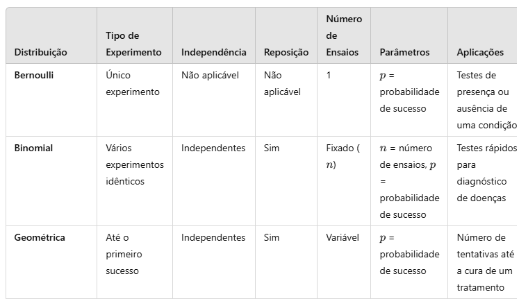

### 🟢 Modelo de Bernoulli

#### 📖 Descrição

A Distribuição de Bernoulli é uma das distribuições discretas mais simples e fundamentais na teoria das probabilidades. Ela modela um experimento aleatório que possui apenas dois resultados possíveis.

Características da Distribuição de Bernoulli

- Eventos Independentes: Cada tentativa é independente das demais.
- Dois Resultados Possíveis: Sucesso (1) ou Fracasso (0).
- Parâmetro: p = Probabilidade de sucesso. 1 − 𝑝 = Probabilidade de fracasso.
- Número de Sucessos (X): X = 0 OU 𝑋 = 1

#### 🔢 Função Massa de Probabilidade (FMP)

É utilizada para representar a ocorrência de um evento binário. O **Modelo de Bernoulli** representa um experimento com **dois resultados possíveis**: **sucesso** ou **fracasso**. A probabilidade de sucesso é denotada por **p**, enquanto a probabilidade de fracasso é **(1 - p)**.

A variável aleatória 𝑋 X em uma distribuição de Bernoulli pode assumir apenas dois valores:

- p = Probabilidade de sucesso 𝑃(𝑋=1)
- 1−p = Probabilidade de fracasso 𝑃(𝑋=0)

A Função de Massa de Probabilidade (FMP) descreve a probabilidade de cada valor que X pode assumir.

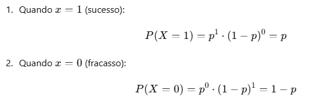

Calcular a probabilidade de um paciente ser curado (sucesso) em um tratamento experimental com 70% de chance de eficácia.

```python
from scipy.stats import bernoulli

p = 0.7  # Probabilidade de sucesso (cura)
x = 1  # Sucesso

probabilidade = bernoulli.pmf(x, p)
print(f"Probabilidade de cura: {probabilidade:.4%}")
```

```
Probabilidade de cura: 70.0000%
```

#### 📝 Propriedades da Distribuição de Bernoulli

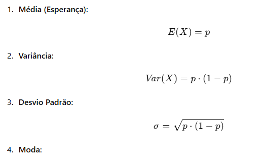

A moda da distribuição de Bernoulli é:

- 1, se 𝑝 > 0.5
- 0, se 𝑝 < 0.5
- Ambos, se 𝑝 = 0.5
- O desvio padrão é a raiz quadrada da variância e representa a dispersão dos resultados em torno da média.
- A média indica o valor esperado da variável aleatória, ou seja, a probabilidade de sucesso.
- A variância mede o grau de dispersão dos valores em torno da média.

```python
from scipy.stats import binom

# Parâmetros da distribuição binomial
n = 10  # Número de ensaios (ex: número de pacientes testados)
p = 0.7 # Probabilidade de sucesso (ex: probabilidade de testar positivo)

# Cálculo das propriedades
media = binom.mean(n, p)
variancia = binom.var(n, p)
desvio_padrao = binom.std(n, p)
mediana = binom.median(n, p)

print(f"Média: {media:.2f}")
print(f"Variância: {variancia:.2f}")
print(f"Desvio Padrão: {desvio_padrao:.2f}")
print(f"Mediana: {mediana:.2f}")
```

```
Média: 7.00
Variância: 2.10
Desvio Padrão: 1.45
Mediana: 7.00
```

#### 📊 Gráfico da Função Massa de Probabilidade (FMP)

**Exemplo na Saúde:** Imagine que 80% dos pacientes de uma clínica testem positivo para uma infecção viral. O sucesso é considerado como o teste positivo.

**Gráfico: Distribuição de Bernoulli**

- Sucesso (presença de vírus): ✅
- Fracasso (ausência de vírus): ❌

```python
import numpy as np
import matplotlib.pyplot as plt
import scipy.stats as stats
from scipy.stats import binom
```

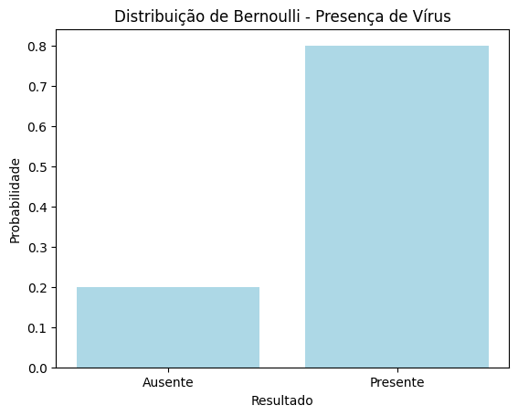

```python
p = 0.8  # Probabilidade de sucesso (ex: presença de vírus em pacientes)
x = [0, 1]  # 0 = fracasso, 1 = sucesso
y = [1 - p, p]
plt.bar(x, y, color='lightblue')
plt.title('Distribuição de Bernoulli - Presença de Vírus')
plt.xlabel('Resultado')
plt.ylabel('Probabilidade')
plt.xticks([0, 1], ['Ausente', 'Presente'])
plt.show()
```

#### 📈 Função de Distribuição Cumulativa (CDF)

CDF calcula a probabilidade acumulada até um certo valor 𝑥:

```python
# Função de Distribuição Cumulativa
cdf = bernoulli.cdf(x, p)

# Exibindo os valores
for valor, prob in zip(x, cdf):
    print(f'P(X ≤ {valor}) = {prob:.2f}')
```

[output not shown]

#### 🛑 Função de Sobrevivência (SF)

A Função de Sobrevivência (SF) é o complemento da CDF e representa a probabilidade de o sucesso não ter ocorrido até o valor x:

```python
# Função de Sobrevivência
sf = bernoulli.sf(x, p)

# Exibindo os valores
for valor, prob in zip(x, sf):
    print(f'P(X > {valor}) = {prob:.2f}')
```

[output not shown]

### 🔵 Modelo Binomial

#### 📖 Descrição

A Distribuição Binomial é uma distribuição de probabilidade discreta que descreve o número de sucessos em uma sequência de n experimentos de Bernoulli independentes, onde cada experimento possui:

- Dois resultados possíveis: Sucesso (1) ou Fracasso (0).
- Probabilidade constante de sucesso (p).
- O número de experimentos (n) é fixo.

A variável aleatória X representa o número de sucessos obtidos em n tentativas.

#### 🔢 Função Massa de Probabilidade

A Função Massa de Probabilidade (FMP) da distribuição binomial descreve a probabilidade de obter exatamente um número específico de sucessos em um número fixo de tentativas, quando cada tentativa tem a mesma probabilidade de sucesso.

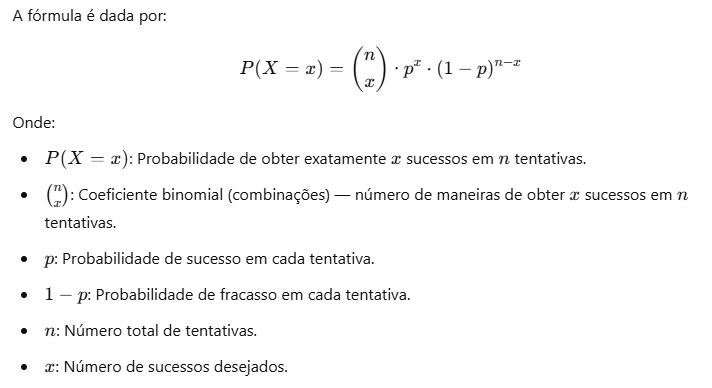

```python
# Parâmetros da distribuição binomial
n = 10  # Número de ensaios (ex: número de pessoas em um estudo)
p = 0.2  # Probabilidade de sucesso em cada ensaio (ex: probabilidade de uma pessoa ter uma certa doença)

# Criando a distribuição binomial
binom_dist = binom(n, p)

# Calculando a probabilidade de obter exatamente k sucessos
k = 3  # Número de sucessos (ex: número de pessoas com a doença)
prob_k_sucessos = binom_dist.pmf(k)
print(f"Probabilidade de exatamente {k} pessoas terem a doença: {prob_k_sucessos}")
```

```
Probabilidade de exatamente 3 pessoas terem a doença: 0.20132659199999992
```

#### 📐 Propriedades da Distribuição Binomial

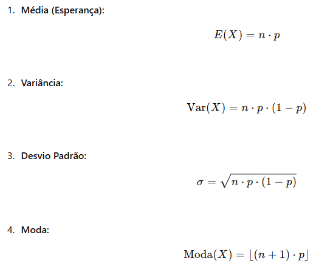

- Média (Esperança): Representa o valor médio esperado de sucessos em uma série de experimentos
- Variância: Representa a dispersão em torno da média
- Desvio padrão: Representa a variação típica em torno da média
- Moda: Representa o valor mais provável (ou que ocorre com mais frequência) de sucessos

**Exemplo:** Um hospital realiza um estudo para avaliar a eficácia de uma nova vacina contra uma doença. Sabe-se que a vacina tem uma eficácia de 70%. O estudo foi realizado com 50 pacientes, e o objetivo é verificar a expectativa e a variabilidade no número de pacientes imunizados.

```python
from scipy.stats import binom

# Parâmetros
n = 50  # Número de pacientes vacinados
p = 0.70  # Probabilidade de sucesso (imunização)

# Cálculo das propriedades usando scipy.stats
media = binom.mean(n, p)
variancia = binom.var(n, p)
desvio_padrao = binom.std(n, p)
moda = binom.median(n, p)

print(f"Média (Esperança): {media}")
print(f"Variância: {variancia}")
print(f"Desvio Padrão: {desvio_padrao:.2f}")
print(f"Moda: {moda}")
```

```
Média (Esperança): 35.0
Variância: 10.500000000000004
Desvio Padrão: 3.24
Moda: 35.0
```

- Média (35): Espera-se que, em média, 35 pacientes desenvolvam imunidade.
- Variância (10.5): A dispersão em torno da média indica uma variabilidade moderada no número de pacientes imunizados.
- Desvio Padrão (3.24): A variação típica em torno da média é de aproximadamente 3 pacientes.
- Moda (35): O valor mais provável de pacientes imunizados também é 35.

Na distribuição binomial, a moda e a média tendem a ser iguais ou muito próximas, especialmente quando:

- O número de tentativas (n) é grande.
- A probabilidade de sucesso (p) está próxima de 0,5.

Para valores extremos de p (muito próximos de 0 ou 1) e poucos experimentos, a moda pode diferir da média, mas, em geral, em situações práticas de saúde, essas diferenças são pequenas.

#### 📊 Gráfico da Função Massa de Probabilidade (FMP)

Vamos plotar a função de massa de probabilidade para observar como a probabilidade se comporta

**Exemplo na Saúde:** Um teste rápido para detecção de uma doença é realizado em 10 pacientes, e a probabilidade de um resultado positivo é de 70%. Queremos calcular a distribuição de resultados positivos.

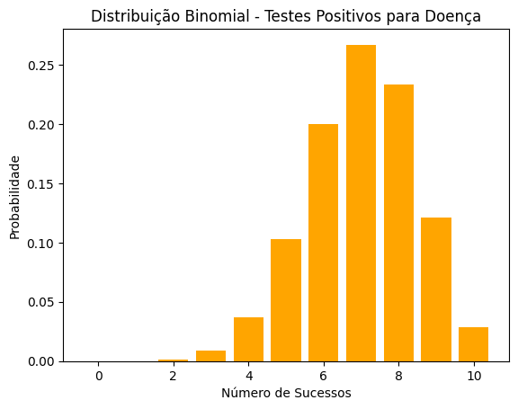

```python
n = 10  # Número de tentativas (ex: pacientes testados)
p = 0.7  # Probabilidade de sucesso (ex: teste positivo para doença)
x = np.arange(0, n+1)
y = stats.binom.pmf(x, n, p) #Código para calcular a função massa de probabilidade para função binomial
plt.bar(x, y, color='orange')
plt.title('Distribuição Binomial - Testes Positivos para Doença')
plt.xlabel('Número de Sucessos')
plt.ylabel('Probabilidade')
plt.show()
```

O gráfico apresentado mostra uma Distribuição Binomial que representa a probabilidade de obter um determinado número de sucessos (número de testes positivos para uma doença) em um conjunto de 10 pacientes testados, considerando que a probabilidade de sucesso (teste positivo) é de 70%.

- Eixo X (Número de Sucessos): Varia de 0 a 10, representando a quantidade de pacientes que tiveram resultado positivo para a doença em um grupo de 10 pacientes testados.
- Eixo Y (Probabilidade): Representa a probabilidade de ocorrência de cada número de sucessos.
- Barras de Probabilidade: Cada barra mostra a probabilidade específica de obter exatamente aquele número de sucessos.
- Moda e Valor mais Provável: O pico do gráfico está no valor de 7 sucessos, indicando que a maior probabilidade é que 7 pacientes testados apresentem teste positivo. Isso faz sentido, pois a média teórica da distribuição é, como veremos abaixo: n⋅p=10⋅0,7=7
- gráfico apresenta uma leve assimetria à esquerda, o que é esperado, já que a probabilidade de sucesso (𝑝=0,7) é relativamente alta.
- Quando a probabilidade é próxima de 0,5, o gráfico é mais simétrico.

#### 📈 Função de Distribuição Cumulativa (CDF)

A CDF da distribuição binomial calcula a probabilidade acumulada de obter até k sucessos em n tentativas:

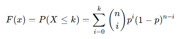

Suponha que, em um hospital, existe uma probabilidade de 10% de um paciente ser internado após uma consulta de emergência. Se houver uma alta probabilidade de ter 5 ou mais internações por semana, será necessário acionar um plantão extra de profissionais.

Naquela semana, o hospital realizou 50 atendimentos de emergência. Qual é a probabilidade de termos que acionar o plantão extra? 🤔

- X = quantidade de internações
- n = 50 atendimentos (número de ensaios)
- p = probabilidade de internação = 10% (0,10)
- q = probabilidade de não internação = 1 - 0,10 = 90% (0,90)

Precisamos calcular a probabilidade de ter 5 ou mais internações. Isso pode ser feito somando as probabilidades de 5, 6, 7,... até 50 internações, usando a Distribuição Binomial

```python
from scipy.stats import binom

# Parâmetros
n = 50  # Número de atendimentos
x = 5   # Número de internações desejadas
p = 0.10  # Probabilidade de internação

# Cálculo da FMP da distribuição binomial
probabilidade = binom.pmf(x, n, p)

print(f"A probabilidade de exatamente 5 internações na semana é: {probabilidade:.4%}")
```

```
A probabilidade de exatamente 5 internações na semana é: 18.4925%
```

#### 🛑 Função de Sobrevivência (SF)

A Função de Sobrevivência (SF) é o complemento da CDF e calcula a probabilidade de obter mais de k sucessos:

Para calcular a probabilidade de haver 5 ou mais internações, precisamos somar as probabilidades de todos os valores possíveis de sucessos a partir de 5 até o número total de tentativas (50):

P(X≥5)=P(X=5)+P(X=6)+P(X=7)+⋯+P(X=50)

A soma dessas probabilidades pode ser simplificada utilizando a função de sobrevivência (SF), que é o complemento da função de distribuição acumulada (CDF):

P(X≥5)=1−P(X<5)

Ou seja:

P(X≥5)=1−CDF(4)

Podemos utilizar a função binom.sf() do pacote scipy.stats para calcular diretamente essa probabilidade:

```python
from scipy.stats import binom

# Parâmetros
n = 50  # Número de atendimentos
p = 0.10  # Probabilidade de internação

# Probabilidade de 5 ou mais internações
probabilidade = binom.sf(4, n, p)  # Complemento da CDF para x >= 5

print(f"A probabilidade de ter 5 ou mais internações na semana é: {probabilidade:.4%}")
```

```
A probabilidade de ter 5 ou mais internações na semana é: 56.8802%
```

### 🔵 Modelo Geométrica

#### 📖 Descrição

A Distribuição Geométrica é uma distribuição discreta que modela o número de tentativas até o primeiro sucesso em uma sequência de experimentos de Bernoulli independentes.

Características da Distribuição Geométrica

- Eventos Independentes: Cada tentativa é independente das demais.
- Dois Resultados Possíveis: Cada tentativa resulta em sucesso (1) ou fracasso (0).
- Número de Tentativas: A variável aleatória X representa o número de tentativas até o primeiro sucesso.
- Parâmetro: p: Probabilidade de sucesso em cada tentativa.

#### 🔢 Função massa de Probabilidade (FMP)

Onde:

- x = Número de tentativas até o primeiro sucesso (𝑥=1, 2, 3,…)
- p = Probabilidade de sucesso em uma tentativa
- 1 − 𝑝 = Probabilidade de fracasso

**Exemplo:** Suponha que um tratamento experimental tem 30% de chance de cura em cada aplicação. Queremos calcular a probabilidade de que a primeira cura aconteça na quarta aplicação.

```python
from scipy.stats import geom

# Parâmetros
p = 0.30  # Probabilidade de sucesso (cura)
x = 4     # Número de tentativas até o primeiro sucesso

# Cálculo da probabilidade
prob = geom.pmf(x, p)
print(f"🌟 A probabilidade de a primeira cura ocorrer na 4ª tentativa é: {prob:.4%}")
```

```
🌟 A probabilidade de a primeira cura ocorrer na 4ª tentativa é: 10.2900%
```

#### 📐 Propriedades da Distribuição Geométrica

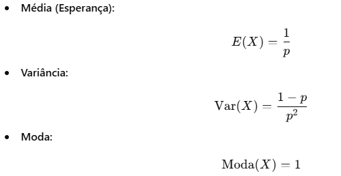

Na distribuição geométrica, a média nos diz o número médio de tentativas até o primeiro sucesso. A variância mede a dispersão dos valores em torno da média, ou seja, o quão espalhados os resultados estão. Se a variância é alta, significa que o número de tentativas até o primeiro sucesso pode variar bastante. Se a variância é baixa, as tentativas até o primeiro sucesso estarão mais próximas da média.

A distribuição geométrica modela o número de tentativas até o primeiro sucesso. Isso significa que o valor mais provável (a moda) é o número 1, pois a primeira tentativa tem a maior probabilidade de ser um sucesso.

**Exemplo:** Imagine que um tratamento tem 20% de chance de sucesso a cada aplicação.

```python
from scipy.stats import geom

# Parâmetro da distribuição geométrica
p = 0.2 # Probabilidade de sucesso

# Cálculo das propriedades
media = geom.mean(p)
variancia = geom.var(p)
desvio_padrao = geom.std(p)
mediana = geom.median(p)

print(f"Média: {media:.2f}")
print(f"Variância: {variancia:.2f}")
print(f"Desvio Padrão: {desvio_padrao:.2f}")
print(f"Mediana: {mediana:.2f}")
```

```
Média: 5.00
Variância: 20.00
Desvio Padrão: 4.47
Mediana: 4.00
```

Isso significa que, em média, você precisará de 5 aplicações para obter o primeiro sucesso. Isso significa que o número de tentativas até o primeiro sucesso pode variar consideravelmente em torno da média (5).

#### 📊 Gráfico da Função Massa de Probabilidade (FMP)

Vamos plotar a função de massa de probabilidade para observar como a probabilidade decai conforme o número de tentativas aumenta.

[figure not shown]

```python
import matplotlib.pyplot as plt
import numpy as np

x = np.arange(1, 20)  # Número de tentativas (1 a 20)
pmf = geom.pmf(x, p)

plt.stem(x, pmf, basefmt=" ")
plt.title("Distribuição Geométrica - Probabilidade de Primeira Cura")
plt.xlabel("Número de Tentativas")
plt.ylabel("Probabilidade")
plt.show()
```

O valor da probabilidade diminui exponencialmente conforme o número de tentativas aumenta. Portanto: A maior probabilidade ocorre na primeira tentativa.

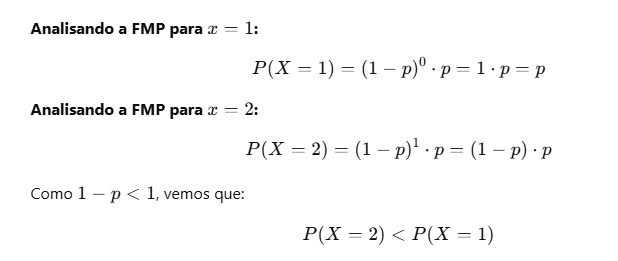

#### 📈 Função de distribuição cumulativa (CDF)

A CDF da distribuição geométrica calcula a probabilidade acumulada de obter o primeiro sucesso até a tentativa x.

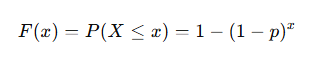

**Exemplo:** Um medicamento tem 30% de chance de cura por aplicação. Qual é a probabilidade de que a primeira cura ocorra até a 4ª aplicação?

```python
from scipy.stats import geom

# Parâmetros
p = 0.30  # Probabilidade de sucesso (cura)
x = 4     # Número de tentativas

# Cálculo da CDF
prob_acumulada = geom.cdf(x, p)
print(f"🌿 Probabilidade de cura até a 4ª aplicação: {prob_acumulada:.4%}")
```

```
🌿 Probabilidade de cura até a 4ª aplicação: 75.9900%
```

#### 🛑 Função sobrevivência (SF)

A SF é o complemento da CDF e calcula a probabilidade de o primeiro sucesso não ter ocorrido até a tentativa X, ou seja, ocorrer após X.

**Exemplo:** Qual é a probabilidade de que a primeira cura ocorra somente após a 4ª aplicação?

```python
# Cálculo da SF
prob_sobrevivencia = geom.sf(x, p)
print(f"🚑 Probabilidade de a cura ocorrer após a 4ª aplicação: {prob_sobrevivencia:.4%}")
```

```
🚑 Probabilidade de a cura ocorrer após a 4ª aplicação: 24.0100%
```

Se o resultado for 24,01%, significa que há 24,01% de probabilidade de o paciente não ser curado até a 4ª aplicação.

## 🎯 Modelos Probabilísticos Discretos Não Dicotômicos ou Binários

Quando a variável aleatória pode assumir mais de dois valores inteiros distintos.

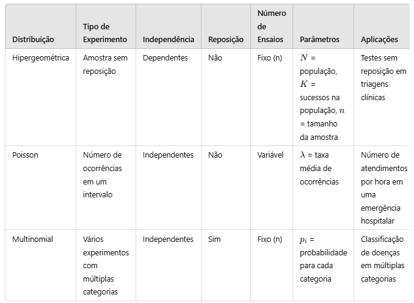

### 🔵 Modelo Hipergeométrica

#### 📖 Descrição

A Distribuição Hipergeométrica é uma distribuição de probabilidade discreta que descreve o número de sucessos em uma amostra extraída sem reposição de uma população finita que contém um número fixo de sucessos e fracassos.

Características:

- População Finita: Contém um total de N elementos.
- Número de Sucessos na População: K (por exemplo, pessoas doentes em um hospital).
- Tamanho da Amostra: n (quantidade de indivíduos extraídos).
- Número de Sucessos na Amostra: x (sucessos observados na amostra).

#### 🔢 Função massa de Probabilidade (FMP)

A FMP da distribuição hipergeométrica é dada por:

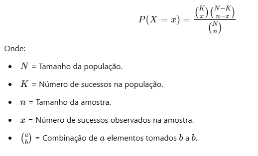

**Exemplo:** Em um hospital com 100 pacientes, sendo 30 positivos para uma doença, selecionamos 10 pacientes para testes rápidos. Qual a probabilidade de encontrar exatamente 5 positivos?

```python
from scipy.stats import hypergeom
import matplotlib.pyplot as plt
import numpy as np

# Parâmetros
N = 100  # Tamanho da população
K = 30   # Número de sucessos na população (positivos)
n = 10   # Tamanho da amostra
x = 5

# Cálculo da probabilidade
prob = hypergeom.pmf(x, N, K, n)
print(f"🌟 A probabilidade é: {prob:.4%}")
```

```
🌟 A probabilidade é: 9.9637%
```

#### 📐 Propriedades da Distribuição Hipergeométrica

Interpretação: O valor esperado representa o número médio de sucessos ao realizar uma amostragem de tamanho 𝑛 n da população.

- Variância:

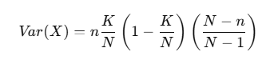

Interpretação: A variância mede o grau de dispersão dos sucessos ao longo da amostra, considerando a correção para amostragem sem reposição.

**Exemplo:** Em um hospital, temos um estoque de 100 kits de diagnóstico para uma determinada doença. Sabemos que 30 desses kits possuem defeito de fabricação. Vamos realizar uma inspeção retirando 10 kits ao acaso para verificar a qualidade. Queremos calcular as propriedades da distribuição (média, variância, desvio padrão e mediana) para a quantidade de kits defeituosos encontrados na amostra.

```python
from scipy.stats import hypergeom

# Parâmetros
N = 100  # Tamanho da população
K = 30   # Número de sucessos na população
n = 10   # Tamanho da amostra

# Cálculo das propriedades
media = hypergeom.mean(N, K, n)
variancia = hypergeom.var(N, K, n)
desvio_padrao = hypergeom.std(N, K, n)
mediana = hypergeom.median(N, K, n)

print(f"Média: {media:.2f}")
print(f"Variância: {variancia:.2f}")
print(f"Desvio Padrão: {desvio_padrao:.2f}")
print(f"Mediana: {mediana:.2f}")
```

```
Média: 3.00
Variância: 1.91
Desvio Padrão: 1.38
Mediana: 3.00
```

Média (3.00): Em média, esperamos encontrar 3 kits defeituosos em cada inspeção de 10 kits.

Variância (1.91): A dispersão em torno da média é relativamente pequena, indicando que os valores não variam muito.

Desvio Padrão (1.38): A quantidade típica de kits defeituosos em torno da média é aproximadamente 1.38, indicando uma variação moderada.

#### 📊 Gráfico da Função Massa de Probabilidade (FMP)

O gráfico exibe a probabilidade de encontrar um número específico de positivos na amostra. As barras mais altas indicam os valores com maior probabilidade.

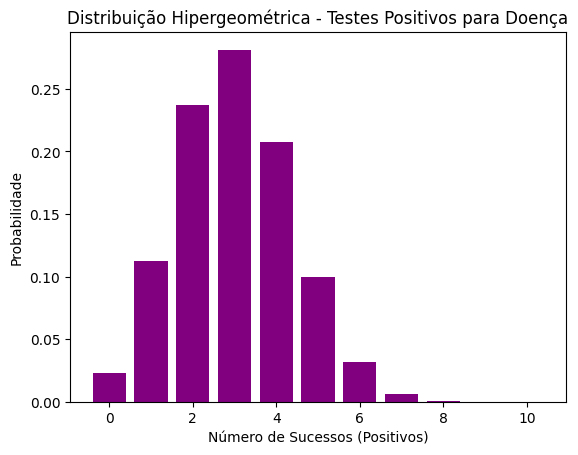

```python
from scipy.stats import hypergeom
import matplotlib.pyplot as plt
import numpy as np

# Parâmetros
N = 100  # Tamanho da população
K = 30   # Número de sucessos na população (positivos)
n = 10   # Tamanho da amostra
x = np.arange(0, n+1)

# Função Massa de Probabilidade
pmf = hypergeom.pmf(x, N, K, n)

# Gráfico da FMP
plt.bar(x, pmf, color='purple')
plt.title('Distribuição Hipergeométrica - Testes Positivos para Doença')
plt.xlabel('Número de Sucessos (Positivos)')
plt.ylabel('Probabilidade')
plt.show()
```

#### 📈 Função de distribuição cumulativa (CDF)

A CDF calcula a probabilidade acumulada de obter até x sucessos:

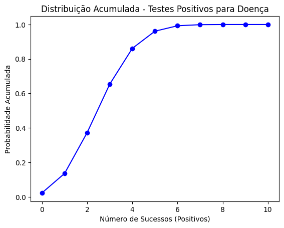

```python
# Função de Distribuição Acumulada (CDF)
cdf = hypergeom.cdf(x, N, K, n)

# Gráfico da CDF
plt.plot(x, cdf, marker='o', linestyle='-', color='blue')
plt.title('Distribuição Acumulada - Testes Positivos para Doença')
plt.xlabel('Número de Sucessos (Positivos)')
plt.ylabel('Probabilidade Acumulada')
plt.show()
```

#### 🛑 Função sobrevivência (SF)

A SF calcula a probabilidade complementar da CDF, ou seja:

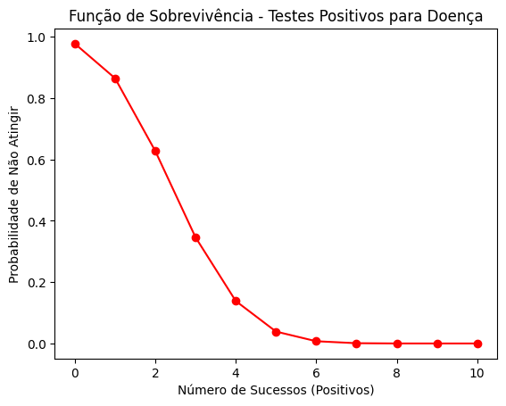

```python
# Função de Sobrevivência (SF)
sf = hypergeom.sf(x, N, K, n)

# Gráfico da SF
plt.plot(x, sf, marker='o', linestyle='-', color='red')
plt.title('Função de Sobrevivência - Testes Positivos para Doença')
plt.xlabel('Número de Sucessos (Positivos)')
plt.ylabel('Probabilidade de Não Atingir')
plt.show()
```

### 🟣 Modelo de Poisson

#### 📖 Descrição

O **Modelo de Poisson** é usado para modelar o número de ocorrências de um evento em um intervalo de tempo fixo, dado que as ocorrências são independentes e a média de ocorrências por intervalo é conhecida.

- Eventos Independentes: A ocorrência de um evento não afeta a ocorrência de outro.
- Taxa Constante (𝜆): A taxa de eventos por intervalo é fixa.
- Probabilidade Proporcional: A probabilidade depende diretamente da média e do número de eventos desejados.

#### 🔢 Função massa de Probabilidade (FMP)

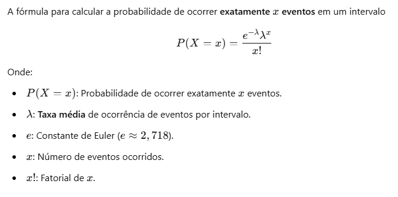

Um hospital possui uma unidade de emergência que atende, em média, 12 pacientes por hora. No entanto, a administração está preocupada com momentos de alta demanda, quando há 15 ou mais pacientes em uma única hora.

Para garantir que haja profissionais suficientes no plantão, o gestor deseja saber:

📊 Qual é a probabilidade de atender exatamente 15 pacientes em uma hora?

```python
from scipy.stats import poisson

# Parâmetros
media = 12  # Média de pacientes por hora
x = 15  # Número de pacientes desejado

# 1. Probabilidade de exatamente 15 pacientes
prob_15 = poisson.pmf(x, media)
print(f"📊 A probabilidade de atender exatamente 15 pacientes em uma hora é: {prob_15:.4%}")
```

```
📊 A probabilidade de atender exatamente 15 pacientes em uma hora é: 7.2391%
```

#### 📐 Propriedades da Distribuição de Poisson

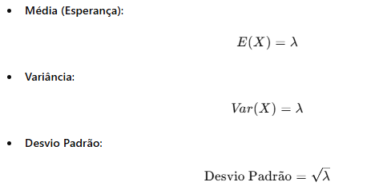

```python
lambda_value = 5  # Taxa média de ocorrências
x = np.arange(0, 15)  # Valores possíveis para X

# Cálculo das propriedades
media = poisson.mean(lambda_value)
variancia = poisson.var(lambda_value)
desvio_padrao = poisson.std(lambda_value)

print(f"Média (Esperança): {media:.2f}")
print(f"Variância: {variancia:.2f}")
print(f"Desvio Padrão: {desvio_padrao:.2f}")
```

```
Média (Esperança): 5.00
Variância: 5.00
Desvio Padrão: 2.24
```

#### 📊 Gráfico da Função Massa de Probabilidade (FMP)

Vamos plotar um gráfico para entender como a probabilidade se distribui:

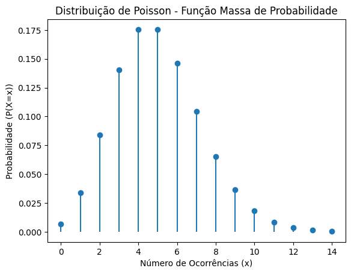

```python
# Parâmetros da distribuição
lambda_value = 5  # Taxa média de ocorrências
x = np.arange(0, 15)  # Valores possíveis para X
pmf = poisson.pmf(x, lambda_value)

# Gráfico da FMP
plt.stem(x, pmf, basefmt=" ")
plt.title('Distribuição de Poisson - Função Massa de Probabilidade')
plt.xlabel('Número de Ocorrências (x)')
plt.ylabel('Probabilidade (P(X=x))')
plt.show()
```

O gráfico mostra a probabilidade de obter um determinado número de ocorrências em um intervalo fixo. A distribuição é assimétrica para valores baixos de 𝜆, e mais simétrica para valores maiores.

#### 📈 Função de distribuição cumulativa (CDF)

A CDF da distribuição de Poisson calcula a probabilidade acumulada de até um certo número de ocorrências:

Para garantir que haja profissionais suficientes no plantão, o gestor deseja saber:

```python
# 2. Probabilidade de 15 ou mais pacientes
prob_15_ou_mais = poisson.sf(14, media)  # SF é o complemento da CDF
print(f"📈 A probabilidade de atender 15 ou mais pacientes em uma hora é: {prob_15_ou_mais:.4%}")
```

[output not shown]

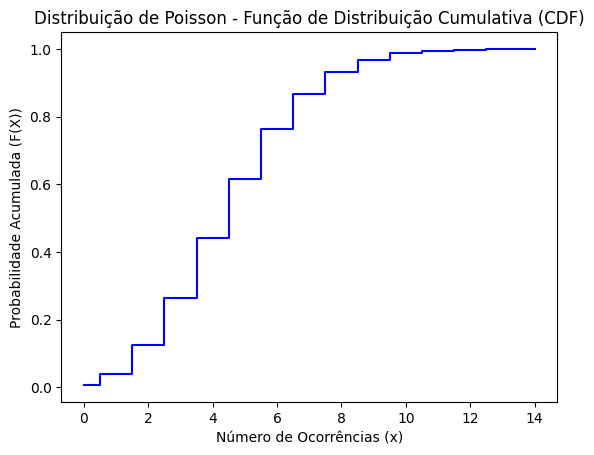

```python
from scipy.stats import poisson

# Cálculo da CDF
cdf = poisson.cdf(x, lambda_value)

# Gráfico da CDF
plt.step(x, cdf, where='mid', color='blue')
plt.title('Distribuição de Poisson - Função de Distribuição Cumulativa (CDF)')
plt.xlabel('Número de Ocorrências (x)')
plt.ylabel('Probabilidade Acumulada (F(X))')
plt.show()
```

#### 🛑 Função sobrevivência (SF)

A SF da distribuição de Poisson calcula a probabilidade de que o número de ocorrências seja maior que um valor específico:

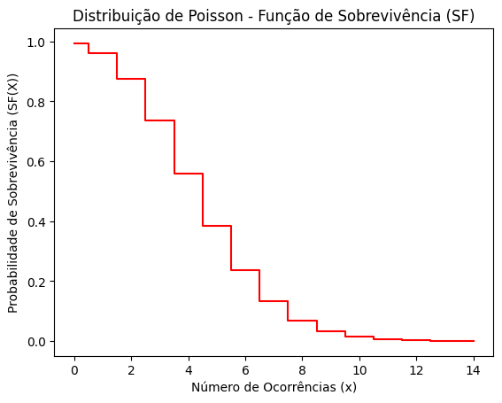

```python
# Cálculo da SF
sf = poisson.sf(x, lambda_value)

# Gráfico da SF
plt.step(x, sf, where='mid', color='red')
plt.title('Distribuição de Poisson - Função de Sobrevivência (SF)')
plt.xlabel('Número de Ocorrências (x)')
plt.ylabel('Probabilidade de Sobrevivência (SF(X))')
plt.show()
```